# ML Wk4 Project_B

## R Markdown

Machine Learning end of Course Project

The goal of the project is to determine how well participants performed weight lifting excercise. A sensor was attached to participant body,it measured and recorded how well each participant performed each exercise. Performance was rated from A – E. There were 19,622 records in training set and 20 records in test set, with 160 variables. Data can be found here https://d396qusza40orc.cloudfront.net/predmachlearn/pml-training.csv; https://d396qusza40orc.cloudfront.net/predmachlearn/pml-testing.csv

I read in data with readr package and read_csv function. The first task was to use summary(), head() and str() functions to understand data. Summary() showed there were many variables with values = NA. Next I used dplyr package and ggplot2 packages to summarize data by user_name and classe. Classe is the grade assigned to performance for each activity. User_name was the identifier for each participant, there were 6 participants. Table below summarizes each user grade from A-E.

```r
sumtrain
```

```
##             A   B   C   D   E
## adelmo   1165 776 750 515 686
## carlitos  834 690 493 486 609
## charles   899 745 539 642 711
## eurico    865 592 489 582 542
## jeremy   1177 489 652 522 562
## pedro     640 505 499 469 497
```

Also see Appendix A or MLProjectPlot1.png and Appendix B or MLProjectPlot2.png for graphs of distribution of user_name and classe variables

Next I used the nzv() function to exclude some variables, this resulted in training set with 56 variables but test set with 59 variables. I looked at details of the 3 variables in the test set that was excluded from the training set, some had negative values. I decided to also exclude them from the training set , with the intention of revisiting if prediction had low accuracy without them. Said variables excluded are Magnet_dumbell_z, magnet_forearm_y and magnet_forearm_z. I also excluded the X variable from both test and training set. These variables are index variables and will not add value to prediction. I finally ended up with 54 predictors (see Appendix III) plus ‘classe’– the response variable.

The plan -use a decision tree, random forest and boosting or a combination to get 99% accuracy. I would train on cleansed data and use the 3 methods or a combination. Only employ cross validation, principal process analysis and scaling and centering of the predictors only if I did not get over 99% accuracy without them

```
## CART
##
## 19622 samples
##    54 predictor
##     5 classes: 'A', 'B', 'C', 'D', 'E'
##
## No pre-processing
## Resampling: Bootstrapped (25 reps)
## Summary of sample sizes: 19622, 19622, 19622, 19622, 19622, 19622, ...
## Resampling results across tuning parameters:
##
##   cp          Accuracy   Kappa
##   0.02934055  0.7002637  0.61959761
##   0.02944737  0.7002637  0.61959761
##   0.11515454  0.3367671  0.07919019
##
## Accuracy was used to select the optimal model using  the largest value.
## The final value used for the model was cp = 0.02944737.
```

```r
rpart$finalModel
```

```
## n= 19622
##
## node), split, n, loss, yval, (yprob)
##       * denotes terminal node
##
## 1) root 19622 14042 A (0.28 0.19 0.17 0.16 0.18)
##   2) roll_belt< 130.5 17977 12411 A (0.31 0.21 0.19 0.18 0.11) *
##   3) roll_belt>=130.5 1645    14 E (0.0085 0 0 0 0.99) *
```

I started with decision tree, it only gave 70% accuracy in training set, using the Caret package train(). Confusion matrix, shows a lot of inaccuracy across all scores.

```r
confusionMatrix(rpart)
```

```
## Bootstrapped (25 reps) Confusion Matrix
##
## (entries are percentual average cell counts across resamples)
##
##           Reference
## Prediction    A    B    C    D    E
##          A 23.4  4.2  1.2  1.6  0.4
##          B  1.2 10.4  0.7  0.3  1.2
##          C  2.5  3.9 14.1  4.3  1.4
##          D  1.0  0.8  1.1  9.0  2.1
##          E  0.4  0.0  0.2  1.2 13.1
##
##  Accuracy (average) : 0.7002
```

Also, rpart$finalModel and decision tree plot (Appendix C or WeightTrainTree2.png) only show predictor roll_belt variable for predicting. Train(method ’”rpart”) ignored all other variables. But the varImp() on the model shows the following variable importance.

```r
varImp(rpart)
```

```
## rpart variable importance
##
##   only 20 most important variables shown (out of 76)
##
##                                  Overall
## roll_belt                         100.00
## pitch_forearm                      73.05
## accel_belt_z                       61.15
## magnet_belt_y                      57.99
## total_accel_belt                   50.23
## total_accel_dumbbell                0.00
## `cvtd_timestamp05/12/2011 14:24`    0.00
## `cvtd_timestamp05/12/2011 11:23`    0.00
## gyros_dumbbell_y                    0.00
## total_accel_arm                     0.00
## `cvtd_timestamp02/12/2011 13:35`    0.00
## total_accel_forearm                 0.00
## `cvtd_timestamp30/11/2011 17:11`    0.00
## magnet_dumbbell_x                   0.00
## gyros_dumbbell_z                    0.00
## `cvtd_timestamp30/11/2011 17:12`    0.00
## `cvtd_timestamp02/12/2011 14:58`    0.00
## `cvtd_timestamp02/12/2011 14:57`    0.00
## accel_forearm_z                     0.00
## magnet_arm_z                        0.00
```

I thought decision tree plot and varImp() results were a contradiction. I also got very different results if I use base R rpart() vs Caret train(method=”rpart”) for training. At this point I decided to go on to random forest and boosting.

Next I trained data using Caret package train() for random forests. To decrease run time I used traincontrol() with train(). The result was 99.9% accuracy and .03% error rate on the training set,

```r
rf
```

```
## Random Forest
##
## 19622 samples
##    54 predictor
##     5 classes: 'A', 'B', 'C', 'D', 'E'
##
## No pre-processing
## Resampling: Cross-Validated (10 fold)
## Summary of sample sizes: 17658, 17660, 17659, 17662, 17660, 17659, ...
## Resampling results across tuning parameters:
##
##   mtry  Accuracy   Kappa
##    2    0.9906737  0.9882012
##   39    0.9995414  0.9994200
##   76    0.9994395  0.9992910
##
## Accuracy was used to select the optimal model using  the largest value.
## The final value used for the model was mtry = 39.
```

I thought result was pretty good and no need to adjust predictors or use any other method if prediction on test set was up to 95% accurate. Next I looked at the important variables(appendix I), just to have an idea what was driving prediction. Also, if I needed to revisit Decision Tree, it would give me an idea what variables to include/exclude. Since accuracy was over 99% with random forest on training set, I thought data was clean and standardized enough, no need for further processing. Next I used the predict() to make predictions on the test set, the result was;

```r
rfpred <-predict(rf,newdata = testing)
rfpred
```

```
##  [1] B A B A A E D B A A B C B A E E A B B B
## Levels: A B C D E
```

Actual user performance was not included in test set, I took quiz to see how good the predictions were, the result- 20 out of 20 predictions were correct. Though test set sample size was only 20, 100% accuracy was impressive. I decided random forest was a good model to predict this exercise and no further refinement of training set was needed.

Appendix A

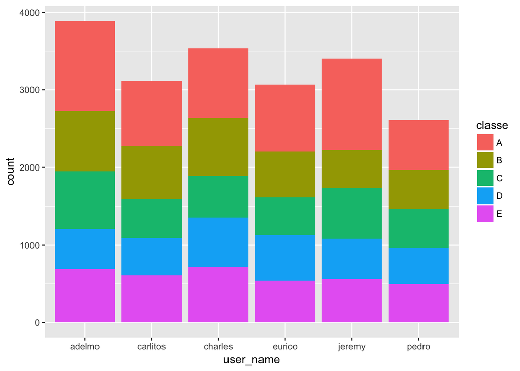

```r
g+geom_bar()
```

Appendix B

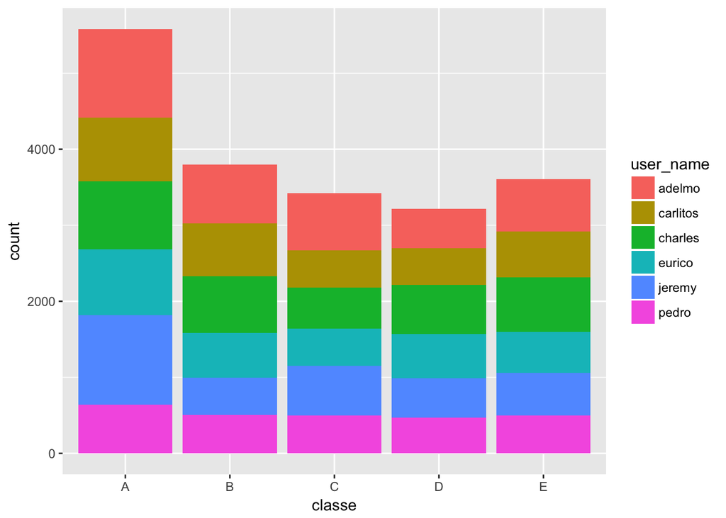

```r
h+geom_bar()
```

Appendix C

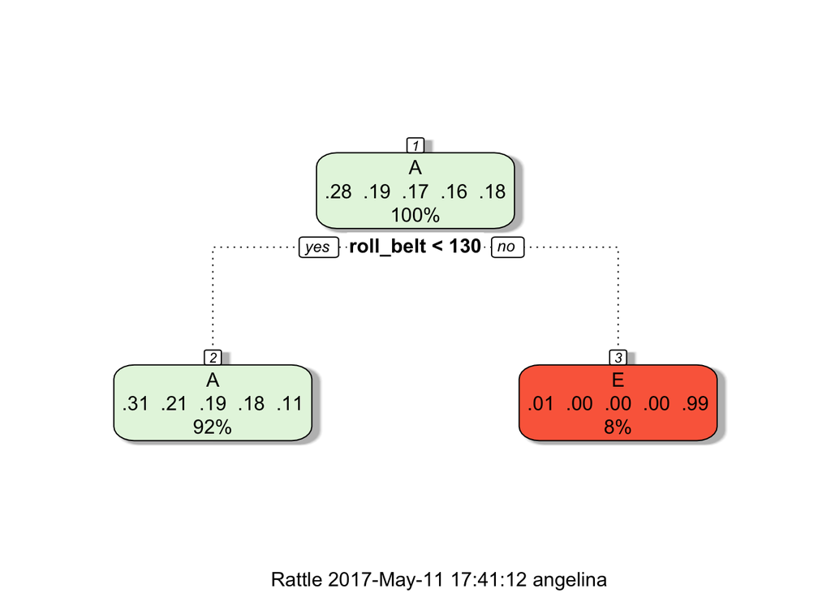

```r
fancyRpartPlot(rpart$finalModel)
```

Appendix I – Random Forest Important variables

```r
varImp(rf)
```

```
## rf variable importance
##
##   only 20 most important variables shown (out of 76)
##
##                                Overall
## raw_timestamp_part_1           100.000
## num_window                      49.822
## roll_belt                       44.033
## pitch_forearm                   26.603
## pitch_belt                      17.166
## magnet_dumbbell_y               16.056
## roll_forearm                    14.052
## yaw_belt                        13.142
## cvtd_timestamp30/11/2011 17:12  11.410
## cvtd_timestamp02/12/2011 14:58   9.756
## cvtd_timestamp28/11/2011 14:15   9.598
## cvtd_timestamp02/12/2011 13:33   8.527
## magnet_dumbbell_x                7.272
## cvtd_timestamp05/12/2011 11:24   6.843
## accel_belt_z                     6.371
## roll_dumbbell                    5.539
## accel_forearm_x                  5.259
## cvtd_timestamp02/12/2011 13:35   5.189
## accel_dumbbell_y                 5.128
## cvtd_timestamp02/12/2011 14:57   5.053
```

Appendix III – Predictors used in Training Set

```
##  [1] "user_name"            "raw_timestamp_part_1" "raw_timestamp_part_2"
##  [4] "cvtd_timestamp"       "num_window"           "roll_belt"
##  [7] "pitch_belt"           "yaw_belt"             "total_accel_belt"
## [10] "gyros_belt_x"         "gyros_belt_y"         "gyros_belt_z"
## [13] "accel_belt_x"         "accel_belt_y"         "accel_belt_z"
## [16] "magnet_belt_x"        "magnet_belt_y"        "magnet_belt_z"
## [19] "roll_arm"             "pitch_arm"            "yaw_arm"
## [22] "total_accel_arm"      "gyros_arm_x"          "gyros_arm_y"
## [25] "gyros_arm_z"          "accel_arm_x"          "accel_arm_y"
## [28] "accel_arm_z"          "magnet_arm_x"         "magnet_arm_y"
## [31] "magnet_arm_z"         "roll_dumbbell"        "pitch_dumbbell"
## [34] "yaw_dumbbell"         "total_accel_dumbbell" "gyros_dumbbell_x"
## [37] "gyros_dumbbell_y"     "gyros_dumbbell_z"     "accel_dumbbell_x"
## [40] "accel_dumbbell_y"     "accel_dumbbell_z"     "magnet_dumbbell_x"
## [43] "magnet_dumbbell_y"    "roll_forearm"         "pitch_forearm"
## [46] "yaw_forearm"          "total_accel_forearm"  "gyros_forearm_x"
## [49] "gyros_forearm_y"      "gyros_forearm_z"      "accel_forearm_x"
## [52] "accel_forearm_y"      "accel_forearm_z"      "magnet_forearm_x"
## [55] "classe"
```